# Descriptive statistics

December 2, 2018

## Statystyki opisowe

dział statystyki zajmujący się metodami opisu danych statystycznych uzyskanych podczas badania statystycznego. Celem stosowania metod statystyki opisowej jest podsumowanie zbioru danych i wyciągnięcie pewnych podstawowych wniosków i uogólnień na temat zbioru.

Statystykę opisową stosuje się zazwyczaj jako pierwszy i podstawowy krok w analizie zebranych danych.

## Podstawowe techniki

- opis tabelaryczny
- graficzna prezentacja wyników
- wyznaczenie miar rozkładu

## Załóżmy, że wektor x składa się z następujących danych

**1 8 2 6 3 8 5 5 5 5**

1. Znajdź różnicę pomiędzy największą a najmniejszą składową wektora x

## Załóżmy, że wektor x składa się z następujących danych

1. Znajdź różnicę pomiędzy największą a najmniejszą składową wektora x

```r
x <- c(1, 8, 2, 6, 3, 8, 5, 5, 5, 5)
max(x) - min(x)
```

```
## [1] 7
```

## Miary rozrzutu danych:

- rozstęp (różnica między największą a najmniejszą wartością zbioru danych),
- wariancja,
- odchylenie standardowe,
- odchylenie ćwiartkowe.

## Zadanie

Zmierzyłeś wysokość 5 cylindrów samochodowych:

**2.1, 3.4, 2.5, 2.7, 2.9**

i ich średnice:

**0.3, 0.5, 0.6, 0.9, 1.1**

1. Zapisz te dane w wektorach, następnie oblicz pojemności cylindrów i zapisz je.
2. Zaimplementuj wzór na odchylenie standardowe i oblicz jego wartość dla pojemności cylindrów.

## Zadanie

```r
wysokosc <- c(2.1, 3.4, 2.5, 2.7, 2.9)  ## zapisujemy dane
srednica <- c(0.3, 0.5, 0.6, 0.9, 1.1)
vol <- wysokosc * pi * (srednica/2)^2  ## objętość
sr <- mean(vol)  ## przyda nam sie srednia
war <- sum((vol - sr))^2/(length(vol) - 1)  ## wariancja
war
```

```
## [1] 1.109336e-31
```

```r
sqrt(war)  ## sd to pierwiastek kwadratowy z wariancji
```

```
## [1] 3.330669e-16
```

## Mediana:

- mediana to sposób wyznaczenia “środka danych”
- można ją utożsamiać z wartością środkową zbioru
- jest to wartość, która dzieli uporządkowany zbiór na dwie równe połowy

## Mediana - przykład

```r
przyklad <- c(1, 11.5, 6, 7.2, 4, 8, 9, 10, 6.8, 8.3, 2, 2,
    10, 1)
sort(przyklad)
```

[1] 1.0 1.0 2.0 2.0 4.0 6.0 6.8 7.2 8.0 8.3 9.0 10.0 10.0 11.5

### a jaka funkcja w R oblicza medianę?

## Mediana - przykład

```r
przyklad <- c(1, 11.5, 6, 7.2, 4, 8, 9, 10, 6.8, 8.3, 2, 2,
    10, 1)
sort(przyklad)
```

[1] 1.0 1.0 2.0 2.0 4.0 6.0 6.8 7.2 8.0 8.3 9.0 10.0 10.0 11.5

### a jaka funkcja w R oblicza medianę?

```r
median(przyklad)
```

[1] 7

## Percentyle:

- dzielą dane na sto grup;
- n-ty percentyl to taka wartość, poniżej której znajduje się n procent danych;
- w dużych zbiorach danych, mediana jest pięćdziesiątym percentylem;
- mediana dolnej połowy danych, czyli dwudziesty piąty percentyl zwana jest również pierwszym kwartylem (Q1);
- mediana górnej połowy danych, czyli siedemdziesiąty piąty percentyl zwana jest również trzecim kwartylem (Q3).

## Przykład

```r
przyklad <- c(1, 11.5, 6, 7.2, 4, 8, 9, 10, 6.8, 8.3, 2, 2,
    10, 1)
summary(przyklad)  ## wyświetla garść podstawowych statystyk opisowych
```

```
##    Min. 1st Qu.  Median    Mean 3rd Qu.    Max.
##   1.000   2.500   7.000   6.200   8.825  11.500
```

## Wykresy rozkładu empirycznego cechy (zmiennej)

### Histogram

### Wykres pudełkowy

## Histogram

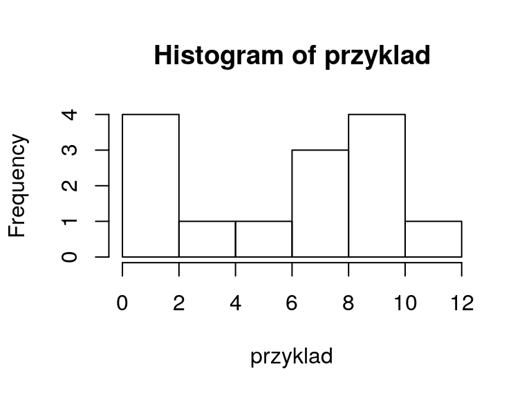

```r
przyklad <- c(1, 11.5, 6, 7.2, 4, 8, 9, 10, 6.8, 8.3, 2, 2,
    10, 1)
hist(przyklad)
```

## Histogram - podstawowe opcje wykresu

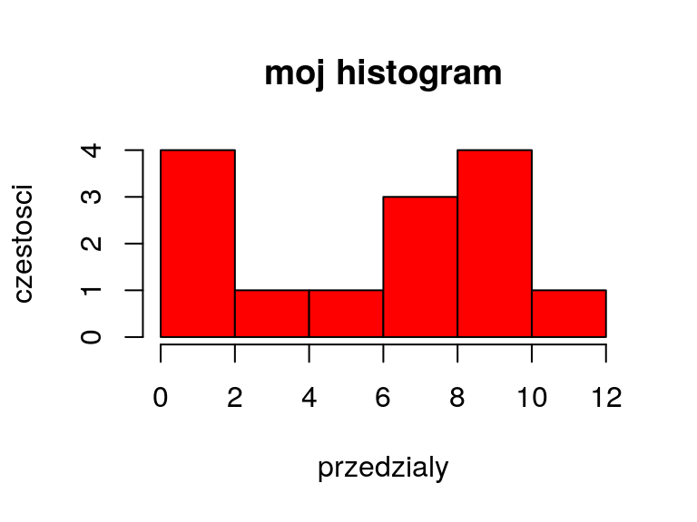

```r
przyklad <- c(1, 11.5, 6, 7.2, 4, 8, 9, 10, 6.8, 8.3, 2, 2,
    10, 1)
hist(przyklad, col = "red", xlab = "przedzialy", ylab = "czestosci",
    main = "moj histogram")
```

## Wykres pudełkowy

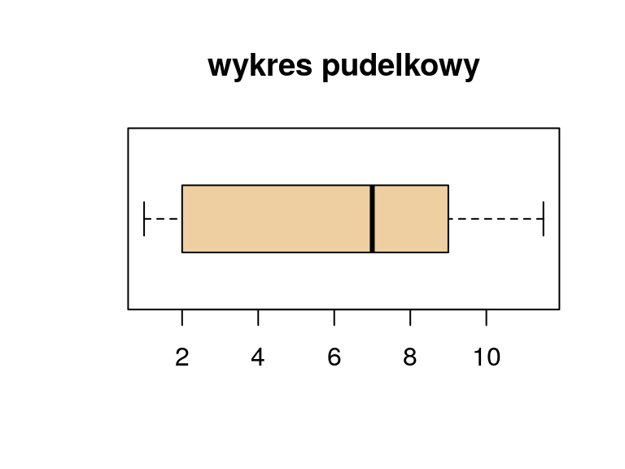

```r
boxplot(przyklad, col = "navajowhite2", main = "wykres pudelkowy",
    horizontal = TRUE)
```

## Skośność danych

Skośność danych miarą asymetrii obserwowanych wyników. Informuje nas o tym jak wyniki dla danej zmiennej kształtują się wokół średniej. Tzn. czy większość zaobserwowanych wyników jest z lewej strony średniej, blisko wartości średniej czy z prawej strony średniej.

- **Asymetria lewostronna → mediana > srednia**
- **Asymetria prawostronna → mediana < srednia**

## Zanieczyszczenie srodowiska

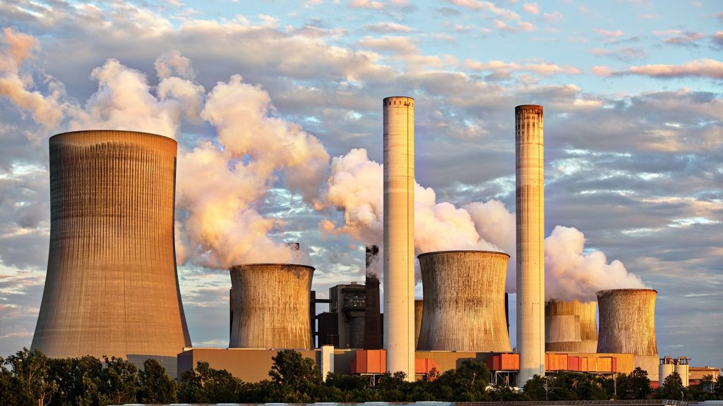

## Dane

Województwo Wielkopolskie +

Powiat Poznań +

Pył zawieszony PM10 - 1 kwiecień - 30 listopad +

Poznań, Chwiałkowskiego –> generuj plik .CSV

## Dane

```r
# importujemy dane
library(readr)
data <- read_delim("~/googledrive/UAM/Stat/cw/sciagi/cw3/gios-pjp-data.csv",
    ";", escape_double = FALSE, trim_ws = TRUE, skip = 1)
## zmienmy nazwy kolumn
colnames(data) <- c("czas", "pm")
```

## Dane

```r
summary(data)  ## garść statystyk opisowych
```

```
##       czas                  pm
##  Min.   :2018-04-01   Min.   : 6.00
##  1st Qu.:2018-05-31   1st Qu.:14.93
##  Median :2018-07-31   Median :22.20
##  Mean   :2018-07-31   Mean   :24.56
##  3rd Qu.:2018-09-29   3rd Qu.:32.23
##  Max.   :2018-11-29   Max.   :90.00
##                       NA's   :33
```

```r
sd(data$pm)  ## odchylenie standardowe, nie działa?
```

```
## [1] NA
```

```r
sd(data$pm, na.rm = TRUE)  ## usuwamy braki danych
```

```
## [1] 13.14827
```

## Dane

```r
sd(data$pm)  ## odchylenie standardowe, nie działa?
```

```
## [1] NA
```

```r
sd(data$pm, na.rm = TRUE)  ## usuwamy braki danych
```

```
## [1] 13.14827
```

## Dane

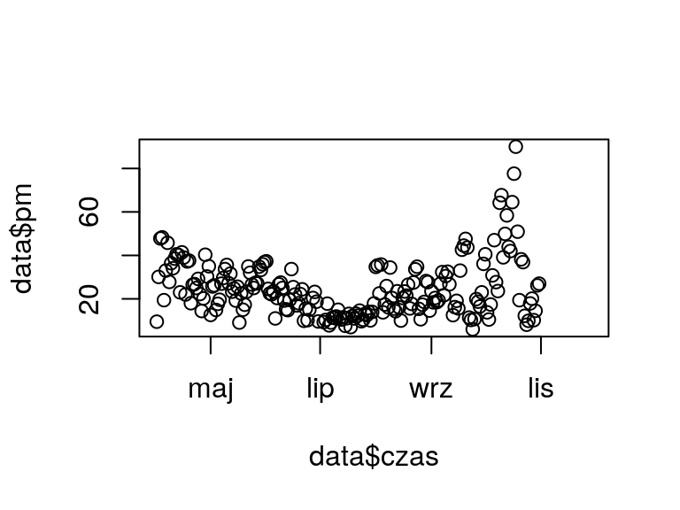

```r
# narysujmy wykres PM 10 w zależności od czasu
plot(data$pm ~ data$czas)
```

## Dane

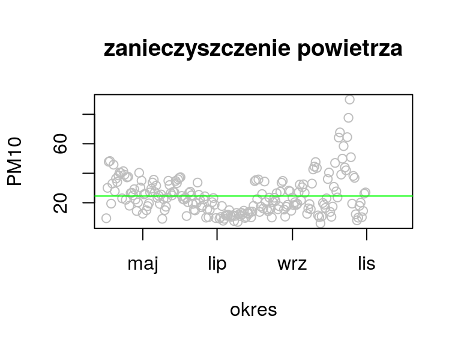

```r
# narysujmy wykres PM 10 w zależności od czasu
plot(data$pm ~ data$czas, col = "grey", xlab = "okres", ylab = "PM10",
    main = "zanieczyszczenie powietrza")
abline(h = mean(data$pm, na.rm = TRUE), col = "green")
```

## Dane

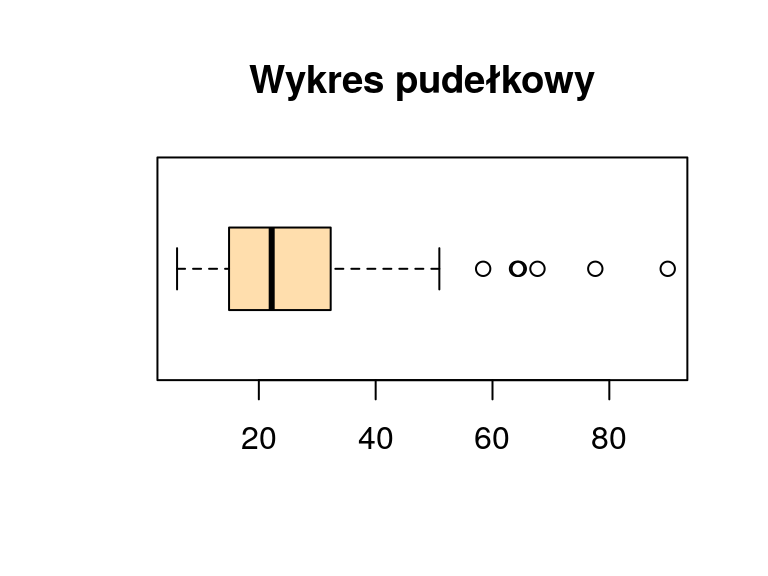

```r
# narysujmy wykres PM 10 w zależności od czasu
boxplot(data$pm, col = "navajowhite", horizontal = TRUE, main = "Wykres pudełkowy")
```

## Ćwiczenie

Ile razy na przestrzeni kwiecień - listopad została przekroczona dobowa norma PM10? Jaki to procent całości?

## Ćwiczenie

Ile razy na przestrzeni kwiecień - listopad została przekroczona dobowa norma PM10? Jaki to procent całości?

```r
sum(data$pm > 50, na.rm = TRUE)  ## ile razy przekroczyliśmy normę?
```

```
## [1] 7
```

```r
sum(is.na(data$pm))  ## ile mamy braków danych?
```

```
## [1] 33
```

```r
(sum(data$pm > 50, na.rm = TRUE)/(length(data$pm) - 33)) *
    100  ## ile to procent całości?
```

```
## [1] 3.333333
```